# Tidying Public Water Quality Data

Matthew Ross

March 29, 2024

# Why public datasets?

Working with large, open-access datasets can serve many purposes. It can be an excellent way to explore new ideas, before investing in field-work or experiments. It can be a great way to take local or experimental results and expand them to different ecosystems, places, or landscapes. Or it can be an excellent way to build, validate, and test ecological models on regional or national scales.

So why doesn’t everyone use public data? Well, it’s often collected by a variety of organizations, with different methods, units, and incosistent metadata. Together these issues with large public datasets, make them “messy.” Messy data can be messy in many different ways, but at the basic level it means that data is hard to analyze, not because the data itself is bad, but because the way it is organized is unclear or inconsistent.

In this lab, we will learn some tricks to “tidying” data, making it analysis-ready. We will depend heavily on the [tidyverse](https://www.tidyverse.org/), an excellent series of packages that make data manipulation beautiful and easy. We will also be working with water quality portal data so we will also use the excellent dataRetrieval package for downloading data from the Water Quality Portal and the USGS.

## Loading key packages

This lab is meant to introduce the incredible variety of tools that one can use to clean data, many of these tools are captured by the `tidyverse` meta-package, a package of packages, but there are some additional ones that will help us locate our various water quality sites.

```r
library(tidyverse) # Package with dplyr, tibble, readr, and others to help clean coding
library(dataRetrieval) # Package to download data.
library(sf) #Geospatial package to plot and explore data
library(mapview) #Simple interface to leaflet interactive maps
library(broom) #Simplifies model outputs
library(knitr) #Makes nice tables
library(kableExtra) #Makes even nicer tables
library(lubridate) #Makes working with dates easier
library(ggthemes) #Makes plots prettier
library(tidyr) #Makes multiple simultaneous models easier
library(trend)
library(ggplot2)
```

# Downloading data.

For this lab, we’ll explore water quality data in the Colorado River basin as it moves from Colorado to Arizona. All data will be generated through the code you see below, with the only external information coming from knowing the SiteID’s for the monitoring locations along the Colorado River and the water quality characteristic names.

The water quality portal can be accessed with the command `readWQPdata`, which takes a variety of parameters (like startdate, enddate, constituents, etc…). We’ll generate these rules for downloading the data here.

## Download prep

```r
#First we'll make a tibble (a tidyverse table) with Site IDs. Generally these are increasingly downstream of the CO headwaters near Grand Lake.
colorado <- tibble(sites=c('USGS-09034500','USGS-09069000','USGS-09071100',
                           'USGS-09085000','USGS-09095500','USGS-09152500',
                           'USGS-09180000','USGS-09180500','USGS-09380000'),
                   basin=c('colorado1','eagle','colorado2',
                           'roaring','colorado3','gunnison',
                           'dolores','colorado4','colorado5'))

#Now we need to setup a series of rules for downloading data from the Water Quality Portal.
#We'll focus on cation and anion data from 1950-present. Each cation has a name that we might typically use like calcium or sulfate, but the name may be different in the water quality portal, so we have to check this website https://www.waterqualitydata.us/Codes/Characteristicname?mimeType=xml to get our names correct.

paramater.names <- c('ca','mg','na','k','so4','cl','hco3')

ca <- c('Calcium')
mg <- c('Magnesium')
na <- 'Sodium'
k <- 'Potassium'
so4 <- c('Sulfate','Sulfate as SO4','Sulfur Sulfate','Total Sulfate')
cl <- 'Chloride'
hco3 <- c('Alkalinity, bicarbonate','Bicarbonate')

#Compile all these names into a single list
parameters <- list(ca,mg,na,k,so4,cl,hco3)
#Name each cation or anion in the list
names(parameters) <- paramater.names
#Notice that we aren't downloading any nutrients (P or N) because they are much messier (100s of different ways to measure and report concentration data) than other cation anion data.

#Start dates
start <- '1980-10-01'
end <- '2024-03-20'

#Sample media (no sediment samples)
sampleMedia = 'Water'

#Comple all this information into a list with arguments
site.args <- list(siteid=colorado$sites,
                  sampleMedia=sampleMedia,
                  startDateLo=start,
                  startDateHi=end,
                  characteristicName=NA) #We'll fill this in later in a loop
```

## Concentration data download

Now that we have generated the commands to download the data, the code to download the data is here, but it is not run on purpose because it takes 15 minutes or so to run everytime. You can always run it yourself by setting `eval=T`.

```r
conc.list <- list() #Empty list to hold each data download


#We'll loop over each anion or cation and download all data at our sites for that constituent
for(i in 1:length(parameters)){
  #We need to rename the characteristicName (constituent) each time we go through the loop
  site.args$characteristicName<-parameters[[i]]

  #readWQPdata takes in our site.args list and downloads the data according to those rules
  # time, constituent, site, etc...

  # Don't forget about pipes "%>%"! Pipes pass forward the results of a previous command, so that
  #You don't have to constantly rename variables. I love them.

  conc.list[[i]] <- readWQPdata(site.args) %>%
    mutate(parameter=names(parameters)[i]) #Mutate just adds a new column to the data frame

  #Pipes make the above command simple and succinct versus something more complicated like:

  ## conc.list[[i]] <- readWQPdata(site.args)
  ## conc.list[[i]]$parameter <- names(parameters)[i]
}
```

[output not shown]

```r
#bind all this data together into a single data frame
conc.long <- map_dfr(conc.list,rbind)
```

## Site info download

We also need to download some site info so we can know where these sites are.

```r
#In addition to concentration informatino, we probably want to know some things about the sites
#dplyr::select can help us only keep site information that is useful.

site.info <- whatWQPsites(siteid=colorado$sites) %>%
  dplyr::select(SiteID=MonitoringLocationIdentifier,
                  name=MonitoringLocationName,
                  area=DrainageAreaMeasure.MeasureValue,
                  area.units=DrainageAreaMeasure.MeasureUnitCode,
                  lat=LatitudeMeasure,
                  long=LongitudeMeasure) %>%
  distinct() #Distinct just keeps the first of any duplicates.
```

# Data tidying

Now that we have downloaded the data we need to tidy it up. The water quality portal data comes with an incredible amount of metadata in the form of extra columns. But we don’t need all this extra data. ## Look at the data you downloaded.

There are two data types we downloaded. First site info which has things like lat and long, and second concentration data. We already slightly tidied the site info data so that it has sensible column names

```r
head(site.info)
```

```
## # A tibble: 6 × 6
##   SiteID        name                                 area area.units lat   long
##   <chr>         <chr>                               <dbl> <chr>      <chr> <chr>
## 1 USGS-09380000 COLORADO RIVER AT LEES FERRY, AZ   111800 sq mi      36.8… -111…
## 2 USGS-09034500 COLORADO RIVER AT HOT SULPHUR SPR…    825 sq mi      40.0… -106…
## 3 USGS-09069000 EAGLE RIVER AT GYPSUM, CO             842 sq mi      39.6… -106…
## 4 USGS-09071100 COLORADO RIVER NEAR GLENWOOD SPRI…     NA <NA>       39.5… -107…
## 5 USGS-09085000 ROARING FORK RIVER AT GLENWOOD SP…   1453 sq mi      39.5… -107…
## 6 USGS-09095500 COLORADO RIVER NEAR CAMEO, CO.       7986 sq mi      39.2… -108…
```

This dataset looks nice because it has all the information we need and nothing extra. Now let’s look at the concentration data.

```r
head(conc.long) %>%
  kable(.,'html') %>%
  kable_styling() %>%
  scroll_box(width='800px',height='300px')
```

| OrganizationIdentifier | OrganizationFormalName | ActivityIdentifier | ActivityTypeCode | ActivityMediaName | ActivityMediaSubdivisionName | ActivityStartDate | ActivityStartTime.Time | ActivityStartTime.TimeZoneCode | ActivityEndDate | ActivityEndTime.Time | ActivityEndTime.TimeZoneCode | ActivityDepthHeightMeasure.MeasureValue | ActivityDepthHeightMeasure.MeasureUnitCode | ActivityDepthAltitudeReferencePointText | ActivityTopDepthHeightMeasure.MeasureValue | ActivityTopDepthHeightMeasure.MeasureUnitCode | ActivityBottomDepthHeightMeasure.MeasureValue | ActivityBottomDepthHeightMeasure.MeasureUnitCode | ProjectIdentifier | ActivityConductingOrganizationText | MonitoringLocationIdentifier | ActivityCommentText | SampleAquifer | HydrologicCondition | HydrologicEvent | SampleCollectionMethod.MethodIdentifier | SampleCollectionMethod.MethodIdentifierContext | SampleCollectionMethod.MethodName | SampleCollectionEquipmentName | … |
| --- | --- | --- | --- | --- | --- | --- | --- | --- | --- | --- | --- | --- | --- | --- | --- | --- | --- | --- | --- | --- | --- | --- | --- | --- | --- | --- | --- | --- | --- | --- |
| USGS-CO | USGS Colorado Water Science Center | nwisco.01.98103380 | Sample-Routine | Water | Surface Water | 1980-10-08 | 14:00:00 | MDT | NA | NA | NA | NA | NA | NA | NA | NA | NA | NA | NA | U.S. Geological Survey-Water Resources Discipline | USGS-09152500 | NA | NA | Not determined | Routine sample | USGS | USGS | USGS | Unknown | … |
| USGS-CO | USGS Colorado Water Science Center | nwisco.01.98102592 | Sample-Routine | Water | Surface Water | 1980-10-10 | 11:20:00 | MDT | NA | NA | NA | NA | NA | NA | NA | NA | NA | NA | NA | Organization other than U.S. Geological Survey | USGS-09085000 | NA | NA | Not determined | Routine sample | USGS | USGS | USGS | Unknown | … |
| USGS-CO | USGS Colorado Water Science Center | nwisco.01.98102343 | Sample-Routine | Water | Surface Water | 1980-10-10 | 12:10:00 | MDT | NA | NA | NA | NA | NA | NA | NA | NA | NA | NA | NA | Organization other than U.S. Geological Survey | USGS-09071100 | NA | NA | Not determined | Routine sample | USGS | USGS | USGS | Unknown | … |
| USGS-CO | USGS Colorado Water Science Center | nwisco.01.98102344 | Sample-Routine | Water | Surface Water | 1980-10-15 | 15:45:00 | MDT | NA | NA | NA | NA | NA | NA | NA | NA | NA | NA | NA | Organization other than U.S. Geological Survey | USGS-09071100 | NA | NA | Not determined | Routine sample | USGS | USGS | USGS | Unknown | … |
| USGS-CO | USGS Colorado Water Science Center | nwisco.01.98102593 | Sample-Routine | Water | Surface Water | 1980-10-16 | 13:55:00 | MDT | NA | NA | NA | NA | NA | NA | NA | NA | NA | NA | NA | Organization other than U.S. Geological Survey | USGS-09085000 | NA | NA | Not determined | Routine sample | USGS | USGS | USGS | Unknown | … |
| USGS-UT | USGS Utah Water Science Center | nwisut.01.98100002 | Sample-Routine | Water | Surface Water | 1980-10-21 | 11:00:00 | MDT | NA | NA | NA | NA | NA | NA | NA | NA | NA | NA | NA | U.S. Geological Survey-Water Resources Discipline | USGS-09180000 | NA | NA | Not determined | Routine sample | USGS | USGS | USGS | Unknown | … |

## Initial cleaning up

Wow that looks messy! Lots of extraneous columns, lots of NAs, so much information we can hardly parse it. Let’s pair it down to the essentials.

```r
#This code mostly just grabs and renames the most important data columns
conc.clean <-  conc.long %>%
                  dplyr::select(date=ActivityStartDate,
                         parameter=CharacteristicName,
                         units=ResultMeasure.MeasureUnitCode,
                         SiteID=MonitoringLocationIdentifier,
                         org=OrganizationFormalName,
                         org_id=OrganizationIdentifier,
                         time=ActivityStartTime.Time,
                         value=ResultMeasureValue,
                         sample_method=SampleCollectionMethod.MethodName,
                         analytical_method=ResultAnalyticalMethod.MethodName,
                         particle_size=ResultParticleSizeBasisText,
                         date_time=ActivityStartDateTime,
                         media=ActivityMediaName,
                         sample_depth=ActivityDepthHeightMeasure.MeasureValue,
                         sample_depth_unit=ActivityDepthHeightMeasure.MeasureUnitCode,
                         fraction=ResultSampleFractionText,
                         status=ResultStatusIdentifier) %>%
  #Remove trailing white space in labels
  mutate(units = trimws(units)) %>%
  #Keep only samples that are water samples
  filter(media=='Water') #Some of these snuck through!
```

```r
head(conc.long) %>%
  kable(.,'html') %>%
  kable_styling() %>%
  scroll_box(width='800px',height='300px')
```

| OrganizationIdentifier | OrganizationFormalName | ActivityIdentifier | ActivityTypeCode | ActivityMediaName | ActivityMediaSubdivisionName | ActivityStartDate | ActivityStartTime.Time | ActivityStartTime.TimeZoneCode | ActivityEndDate | ActivityEndTime.Time | ActivityEndTime.TimeZoneCode | ActivityDepthHeightMeasure.MeasureValue | ActivityDepthHeightMeasure.MeasureUnitCode | ActivityDepthAltitudeReferencePointText | ActivityTopDepthHeightMeasure.MeasureValue | ActivityTopDepthHeightMeasure.MeasureUnitCode | ActivityBottomDepthHeightMeasure.MeasureValue | ActivityBottomDepthHeightMeasure.MeasureUnitCode | ProjectIdentifier | ActivityConductingOrganizationText | MonitoringLocationIdentifier | ActivityCommentText | SampleAquifer | HydrologicCondition | HydrologicEvent | SampleCollectionMethod.MethodIdentifier | SampleCollectionMethod.MethodIdentifierContext | SampleCollectionMethod.MethodName | SampleCollectionEquipmentName | … |
| --- | --- | --- | --- | --- | --- | --- | --- | --- | --- | --- | --- | --- | --- | --- | --- | --- | --- | --- | --- | --- | --- | --- | --- | --- | --- | --- | --- | --- | --- | --- |
| USGS-CO | USGS Colorado Water Science Center | nwisco.01.98103380 | Sample-Routine | Water | Surface Water | 1980-10-08 | 14:00:00 | MDT | NA | NA | NA | NA | NA | NA | NA | NA | NA | NA | NA | U.S. Geological Survey-Water Resources Discipline | USGS-09152500 | NA | NA | Not determined | Routine sample | USGS | USGS | USGS | Unknown | … |
| USGS-CO | USGS Colorado Water Science Center | nwisco.01.98102592 | Sample-Routine | Water | Surface Water | 1980-10-10 | 11:20:00 | MDT | NA | NA | NA | NA | NA | NA | NA | NA | NA | NA | NA | Organization other than U.S. Geological Survey | USGS-09085000 | NA | NA | Not determined | Routine sample | USGS | USGS | USGS | Unknown | … |
| USGS-CO | USGS Colorado Water Science Center | nwisco.01.98102343 | Sample-Routine | Water | Surface Water | 1980-10-10 | 12:10:00 | MDT | NA | NA | NA | NA | NA | NA | NA | NA | NA | NA | NA | Organization other than U.S. Geological Survey | USGS-09071100 | NA | NA | Not determined | Routine sample | USGS | USGS | USGS | Unknown | … |
| USGS-CO | USGS Colorado Water Science Center | nwisco.01.98102344 | Sample-Routine | Water | Surface Water | 1980-10-15 | 15:45:00 | MDT | NA | NA | NA | NA | NA | NA | NA | NA | NA | NA | NA | Organization other than U.S. Geological Survey | USGS-09071100 | NA | NA | Not determined | Routine sample | USGS | USGS | USGS | Unknown | … |
| USGS-CO | USGS Colorado Water Science Center | nwisco.01.98102593 | Sample-Routine | Water | Surface Water | 1980-10-16 | 13:55:00 | MDT | NA | NA | NA | NA | NA | NA | NA | NA | NA | NA | NA | Organization other than U.S. Geological Survey | USGS-09085000 | NA | NA | Not determined | Routine sample | USGS | USGS | USGS | Unknown | … |
| USGS-UT | USGS Utah Water Science Center | nwisut.01.98100002 | Sample-Routine | Water | Surface Water | 1980-10-21 | 11:00:00 | MDT | NA | NA | NA | NA | NA | NA | NA | NA | NA | NA | NA | U.S. Geological Survey-Water Resources Discipline | USGS-09180000 | NA | NA | Not determined | Routine sample | USGS | USGS | USGS | Unknown | … |

## Final tidy dataset

Okay that is getting better but we still have lots of extraneous information. For our purposes let’s assume that the sample and analytical methods used by the USGS are reasonable and exchangeable (one method is equivalent to the other). If we make that assumption then the only remaining data we need to clean is to make sure that all the data has the same units.

### Unit Check

```r
table(conc.clean$units)
```

```
##
##  mg/l
## 17395
```

All the data is in mg/L!

We just need to remove these observations with a `dplyr::filter` call and then select an even smaller subset of useful columns, while adding a time object column using the `lubridate::ymd` call.

```r
conc.tidy <- conc.clean %>%
  mutate(date=ymd(date)) %>%
  select(date,
         parameter,
         SiteID,
         conc=value)
```

### Daily data

```r
#The amazing group_by function groups all the data so that the summary
#only applies to each subgroup (site, date, and parameter combination).
#So in the end you get a daily average concentratino for each site and parameter type.
conc.daily <- conc.tidy %>%
  group_by(date,parameter,SiteID) %>%
  summarize(conc=mean(conc,na.rm=T))
```

Taking daily averages looks like it did eliminate 445 observations, meaning these site date combinations had multiple observations on the same day.

# Analyzing data

Now we have a ‘tidy’ dataset. Let’s look at the data we have. First where is the data?

### Map

Here we use the `sf` package to project the site information data into a GIS type data object called a `simple feature (sf)`. The function `st_as_sf` converts the long (x) and lat (y) coordinates into a projected point feature with the EPSG code 4326 (WGS 84). We can then use the `mapview` package and function to look at where these sites are.

```r
#convert site info as an sf object
site.sf <- site.info %>%
  st_as_sf(.,coords=c('long','lat'), crs=4326)


mapview(site.sf )
```

[interactive chart not shown]

So these sites are generally in the Colorado River Basin with increasing size.

## Concentration data

Now that we know where the data is coming from let’s look at the actual data we downloaded using ggplot2

### Calcium only

To keep the plots simple at first let’s look at calcium data by site.

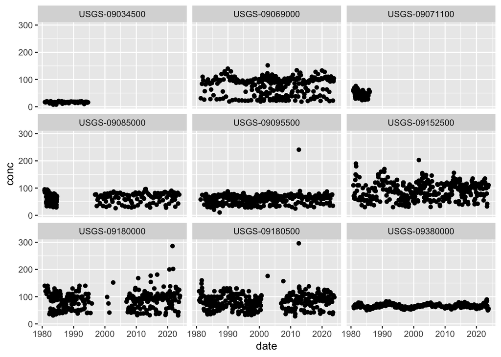

```r
conc.daily %>%
  filter(parameter == 'Calcium') %>%
  ggplot(.,aes(x=date,y=conc)) +
  geom_point() +
  facet_wrap(~SiteID)
```

Okay that’s a lot of data! Maybe too much. Let’s focus in on sites with only continuous datasets and then summarize the data by year

### Annual summaries of full sites

Let’s shrink the dataset to only look at annual change.

```r
too.few.years <- c('USGS-09034500','USGS-0907110','USGS-0908500')

conc.annual <- conc.daily %>%
  filter(!SiteID %in% too.few.years) %>% #! means opposite of, so we want all the sites not in the too.few years vector.
  mutate(year=year(date)) %>%
  group_by(SiteID,year,parameter) %>%
  summarize(annual_mean=mean(conc,na.rm=T),
            annual_var=var(conc,na.rm=T))
```

### Plot all the annual data.

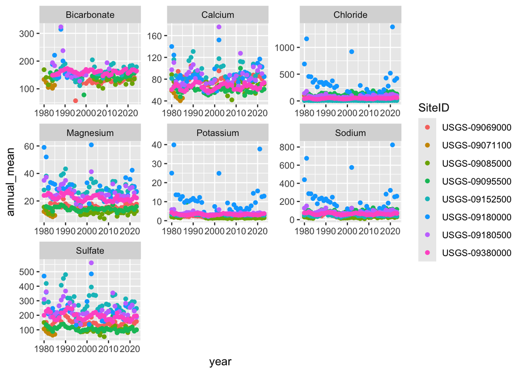

```r
conc.annual %>%
  ggplot(.,aes(x=year,y=annual_mean,color=SiteID)) +
  geom_point() +
  facet_wrap(~parameter,scales='free')
```

That plot is… ugly! Maybe we can make something prettier

### Prettier annual plot.

Having the points colored by SiteID is not super useful, unless you have memorized the name and location of USGS gauge data. So maybe we can color it by the table we used to download the data? That table `colorado` was organized such that each basin had it’s own name or was increasing in basin size. That’s a better way to think about the data than as SiteID names. So let’s use `join` functions to join the datasets and use the basin names. We’ll also use the package `ggthemes` to try and make the plots prettier.

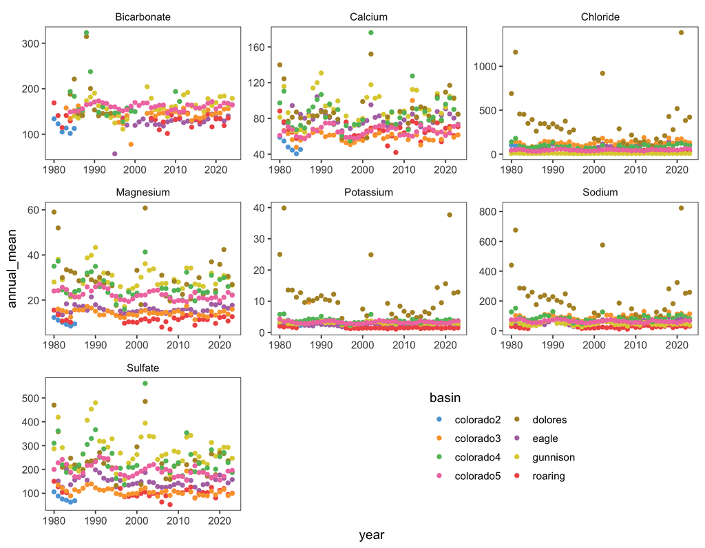

```r
conc.annual %>%
  left_join(colorado %>%
              rename(SiteID=sites),by='SiteID') %>%
  ggplot(.,aes(x=year,y=annual_mean,color=basin)) +
  geom_point() +
  facet_wrap(~parameter,scales='free') +
  theme_few() +
  scale_color_few() +
  theme(legend.position=c(.7,.15)) +
  guides(color=guide_legend(ncol=2))
```

### Watershed size

Many prior publications have shown that increasing watershed size means decreasing variance in anion and cation concentrations. We can use our dataset to test this in the colorado basin.

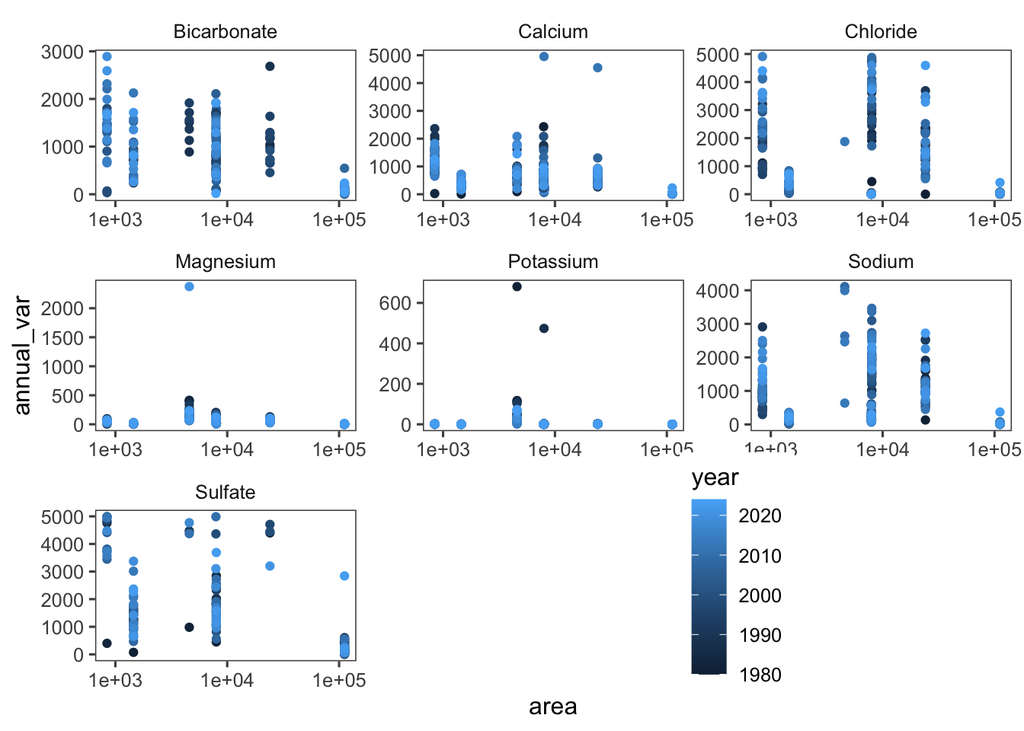

```r
conc.annual %>%
  left_join(site.info,by='SiteID') %>%
  filter(annual_var < 5000) %>%
  ggplot(.,aes(x=area,y=annual_var,color=year)) +
  geom_point() +
  scale_x_log10() +
  facet_wrap(~parameter,scales='free') +
  theme_few() +
  theme(legend.position=c(.7,.15))
```

Cool! Looks like it’s generally true across all constituents. Potassium has low variance. Why? No clue!

## Reshaping the data

From basic weathering geochemistry principles we know that Bicarbonate concentrations should be correlated with Mg and Ca depending on the weathering reactions that generate these river signals. The current shape of the data in a ‘long’ format makes looking at these correlations impossible. So we want to ‘widen’ the data so the parameters are arranged in side by side columns. This is really easy with tidyr `spread` and `gather`!

```r
head(conc.annual)
```

```
## # A tibble: 6 × 5
## # Groups:   SiteID, year [1]
##   SiteID         year parameter annual_mean annual_var
##   <chr>         <dbl> <chr>           <dbl>      <dbl>
## 1 USGS-09069000  1981 Calcium          75      1621
## 2 USGS-09069000  1981 Chloride         64.7    2441.
## 3 USGS-09069000  1981 Magnesium        14.1      54.6
## 4 USGS-09069000  1981 Potassium         2.2       0.79
## 5 USGS-09069000  1981 Sodium           42.6     925.
## 6 USGS-09069000  1981 Sulfate         151      8103
```

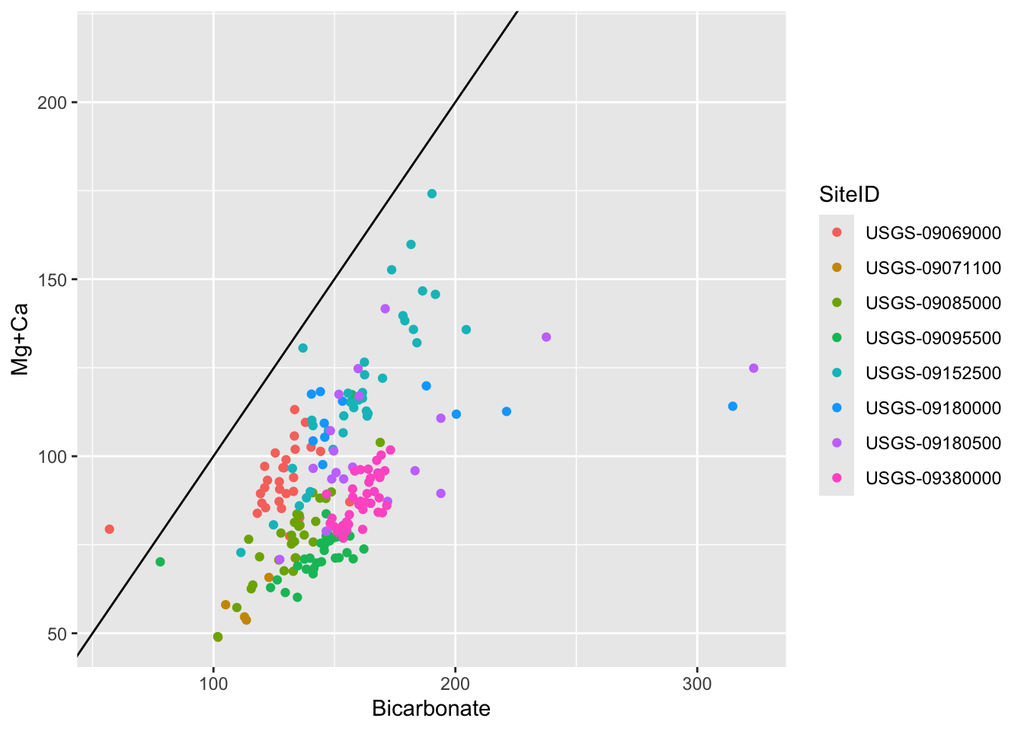

```r
conc.wide <- conc.annual %>%
  select(-annual_var) %>%
  spread(key=parameter,value=annual_mean) %>%
  mutate(`Mg+Ca`=Magnesium+Calcium)


ggplot(conc.wide,aes(x=Bicarbonate,y=`Mg+Ca`,color=SiteID)) +
  geom_point() +
  geom_abline(slope=1,intercept=0)
```

## Model changes

It looks to me like there might be some trends in the data at certain sites. (Mg and SO4 in particular). Let’s use some advanced r to check if there are some linear trends in these datasets.

### Nesting and modelling

There is a really excellent package called purrr and tidyr make doing multiple models on different sites really easy. Quick example here

```r
conc.nest <- conc.annual %>%
  group_by(parameter,SiteID) %>%
  nest()

head(conc.nest)
```

```
## # A tibble: 6 × 3
## # Groups:   parameter, SiteID [6]
##   SiteID        parameter data
##   <chr>         <chr>     <list>
## 1 USGS-09069000 Calcium   <tibble [43 × 3]>
## 2 USGS-09069000 Chloride  <tibble [43 × 3]>
## 3 USGS-09069000 Magnesium <tibble [43 × 3]>
## 4 USGS-09069000 Potassium <tibble [43 × 3]>
## 5 USGS-09069000 Sodium    <tibble [43 × 3]>
## 6 USGS-09069000 Sulfate   <tibble [43 × 3]>
```

That nests or wraps up the data into tidy little bundles. We can access these bundled datasets by using a map function that applies a model *inside* a bundle.

```r
#Create a generic model function (mean as a function of time)
time.lm.models <- function(x){
  mod <- lm(annual_mean~year,data=x)
}

conc.models <- conc.nest %>%
  mutate(mods=map(data,time.lm.models))
```

Now we have an individual time-series analysis model for each site and parameter combination. But how do we see the results in a tidy way? Broom to the rescue!

```r
conc.models %>%
  mutate(mod.glance=map(mods,glance)) %>%
  unnest(mod.glance) %>% #Unnesting unwraps the nested column.
  arrange(desc(adj.r.squared)) %>%
  select(parameter,SiteID,adj.r.squared,p.value,logLik,AIC) %>%
  kable(.,'html') %>%
  kable_styling() %>%
  scroll_box(width='600px',height='500px')
```

| parameter | SiteID | adj.r.squared | p.value | logLik | AIC |
| --- | --- | --- | --- | --- | --- |
| Sodium | USGS-09071100 | 0.8505215 | 0.0055919 | -18.012490 | 42.024980 |
| Chloride | USGS-09071100 | 0.8216059 | 0.0080335 | -21.025592 | 48.051183 |
| Sulfate | USGS-09071100 | 0.7682778 | 0.0137781 | -19.488426 | 44.976853 |
| Calcium | USGS-09071100 | 0.7352453 | 0.0181757 | -14.935576 | 35.871153 |
| Potassium | USGS-09071100 | 0.7341127 | 0.0183382 | 1.949735 | 2.100531 |
| Magnesium | USGS-09071100 | 0.7292619 | 0.0190432 | -5.301195 | 16.602390 |
| Chloride | USGS-09069000 | 0.5150982 | 0.0000000 | -184.247218 | 374.494436 |
| Sodium | USGS-09069000 | 0.4689976 | 0.0000002 | -162.157090 | 330.314180 |
| Bicarbonate | USGS-09071100 | 0.4033104 | 0.1045065 | -20.543928 | 47.087856 |
| Magnesium | USGS-09380000 | 0.2431260 | 0.0003980 | -87.055696 | 180.111391 |
| Potassium | USGS-09069000 | 0.2185269 | 0.0009279 | -7.072389 | 20.144778 |
| Sulfate | USGS-09380000 | 0.2093011 | 0.0010565 | -198.753679 | 403.507358 |
| Chloride | USGS-09085000 | 0.2003561 | 0.0052491 | -118.485540 | 242.971079 |
| Bicarbonate | USGS-09069000 | 0.1926983 | 0.0099710 | -119.634004 | 245.268008 |
| Potassium | USGS-09085000 | 0.1786655 | 0.0082675 | 9.036272 | -12.072543 |
| Chloride | USGS-09095500 | 0.1620623 | 0.0043320 | -198.645337 | 403.290674 |
| Sodium | USGS-09085000 | 0.1541017 | 0.0137096 | -106.503219 | 219.006439 |
| Bicarbonate | USGS-09152500 | 0.1066049 | 0.0293191 | -157.144426 | 320.288852 |
| Sodium | USGS-09095500 | 0.0886679 | 0.0295167 | -179.031311 | 364.062623 |
| Sodium | USGS-09380000 | 0.0805532 | 0.0346443 | -152.634348 | 311.268696 |
| Potassium | USGS-09180500 | 0.0597829 | 0.0698577 | -44.082684 | 94.165369 |
| Sulfate | USGS-09095500 | 0.0597640 | 0.0624041 | -185.834372 | 377.668745 |
| Sulfate | USGS-09069000 | 0.0585130 | 0.0644717 | -194.202439 | 394.404879 |
| Magnesium | USGS-09180000 | 0.0554354 | 0.0864063 | -134.646260 | 275.292519 |
| Bicarbonate | USGS-09180000 | 0.0505978 | 0.2469939 | -58.023338 | 122.046676 |
| Chloride | USGS-09380000 | 0.0454392 | 0.0882044 | -150.416935 | 306.833870 |
| Sulfate | USGS-09180000 | 0.0400666 | 0.1226543 | -209.718199 | 425.436398 |
| Magnesium | USGS-09095500 | 0.0271815 | 0.1480422 | -71.487423 | 148.974846 |
| Magnesium | USGS-09180500 | 0.0103632 | 0.2426893 | -122.367551 | 250.735102 |
| Potassium | USGS-09180000 | 0.0094519 | 0.2542619 | -128.533001 | 263.066001 |
| Sodium | USGS-09152500 | 0.0086033 | 0.2478760 | -167.272022 | 340.544044 |
| Bicarbonate | USGS-09085000 | 0.0063454 | 0.2905254 | -107.639224 | 221.278449 |
| Sodium | USGS-09180500 | 0.0012575 | 0.3121898 | -178.528316 | 363.056632 |
| Sulfate | USGS-09152500 | 0.0009586 | 0.3133711 | -248.864741 | 503.729482 |
| Sodium | USGS-09180000 | 0.0006633 | 0.3185417 | -240.247799 | 486.495598 |
| Sulfate | USGS-09180500 | -0.0021020 | 0.3440066 | -228.412545 | 462.825090 |
| Chloride | USGS-09180000 | -0.0026215 | 0.3477389 | -260.016625 | 526.033251 |
| Potassium | USGS-09095500 | -0.0031343 | 0.3567518 | -62.574697 | 131.149393 |
| Calcium | USGS-09380000 | -0.0048760 | 0.3787597 | -132.826832 | 271.653665 |
| Calcium | USGS-09152500 | -0.0049965 | 0.3802952 | -187.090774 | 380.181547 |
| Sulfate | USGS-09085000 | -0.0072864 | 0.3874177 | -142.531920 | 291.063840 |
| Bicarbonate | USGS-09180500 | -0.0095471 | 0.3750730 | -97.978248 | 201.956496 |
| Bicarbonate | USGS-09380000 | -0.0100246 | 0.4421212 | -138.559648 | 283.119296 |
| Calcium | USGS-09095500 | -0.0103447 | 0.4545851 | -148.601535 | 303.203071 |
| Potassium | USGS-09152500 | -0.0127848 | 0.5026462 | -18.446256 | 42.892512 |
| Potassium | USGS-09380000 | -0.0135277 | 0.5174796 | -15.934683 | 37.869366 |
| Calcium | USGS-09085000 | -0.0142575 | 0.4638291 | -118.370218 | 242.740436 |
| Chloride | USGS-09152500 | -0.0162733 | 0.5797529 | -83.449405 | 172.898810 |
| Calcium | USGS-09180500 | -0.0195401 | 0.6181924 | -177.349005 | 360.698010 |
| Magnesium | USGS-09069000 | -0.0207052 | 0.7024231 | -83.209312 | 172.418623 |
| Magnesium | USGS-09152500 | -0.0212916 | 0.7492079 | -136.810540 | 279.621079 |
| Chloride | USGS-09180500 | -0.0224410 | 0.7064398 | -186.089596 | 378.179191 |
| Calcium | USGS-09069000 | -0.0241495 | 0.9222661 | -152.635248 | 311.270496 |
| Bicarbonate | USGS-09095500 | -0.0250871 | 0.6100680 | -127.481956 | 260.963912 |
| Magnesium | USGS-09085000 | -0.0269819 | 0.6925723 | -63.192007 | 132.384013 |
| Calcium | USGS-09180000 | -0.0273718 | 0.8409599 | -162.070833 | 330.141667 |

Cool! Lots of these constituents have significant trends. Many of them are declining, why? what does that mean for water quality? I don’t know. But we could probably use more public data to investigate.

# Assignment

The above code is… voluminous! But the goal was to show you the full pipeline of downloading, cleaning, harmonizing, analyzing, and displaying public water quality data. For this assignment you will continue to build out your own ability to analyze large complex data.

## Background

The reason so many of these sites in Colorado have lots of chemical concentration data is because the Colorado River is a highly critical resource throughout the Western USA, but it has suffered from impaired water quality, specifically increases in ion concentration leading to high levels of salinity. This is particularly true in the Gunnison River. This occurs both because the bedrock is full of readily weathered ions, and because irrigation practices artificially elevate weathering rates (more water = more ions released). As such the Gunnison River has a salinity control plan (https://gunnisonriverbasin.org/water-quality/salinity-control/).

For this assignment you will be exploring changes in Salinity in the Gunnison River, Dolores River, and the Colorado River above and below where these two rivers join the CO River (all of this is near Grand Junction). The main questions we have are:

1. What are trends in specific conductivity(salinity) in these three rivers since 2007?
2. What is the correlation between specific conductivity and individual ion concentration?
3. How does discharge control these relationships?

## Q1) What are trends in Specific Conductivity?

### Download Spec Cond Data for our Focus Sites.

```r
focus_sites <- colorado <- tibble(sites=c('USGS-09095500','USGS-09152500',
                           'USGS-09180000','USGS-09180500'),
                   basin=c('colorado_above','gunnison',
                           'dolores','colorado_below'))

sc_code = '00095'
# You will need to use readNWISdv function to download daily spec cond data
# for these sites. Data starts in 2007. Pay attention to how that function
# differs from readWQPdata. Consider also using the renameNWIScolumns funciton to
# make this data easier to read.


# Define parameters
siteNumbers <- gsub("USGS-", "", focus_sites$sites)

parameterCd <- '00095' # Flow parameter code

# Define start and end dates
startDate <- '2007-01-01'
endDate <- '2024-03-20'

# Retrieve data
nwis_data <- readNWISdv(siteNumbers = siteNumbers,
                        parameterCd = parameterCd,
                        startDate = startDate,
                        endDate = endDate) %>%
  renameNWISColumns() %>%
  mutate(site_no=paste0("USGS-",site_no))



# You will need to use readNWISdv function to download daily spec cond data
# for these sites. Data starts in 2007. Pay attention to how that function
# differs from readWQPdata. Consider also using the renameNWIScolumns funciton to
# make this data easier to read.
```

### Summarize the daily data to annual means for lower flow periods (July/Aug/Sept/Oct)

Salinity is primarily an issue during low flow periods so when we are looking for trends we want to focus on the saltiest times of year, generally July-Oct.

```r
#Group_by, filter, and summarize will be key here.

nwis_filtered<-nwis_data %>%
  mutate(year=year(.$Date),
    month=month(.$Date)) %>%
  filter(month=="7" | month=="8" | month=="9" | month=="10") %>%
  select(date=Date,site_no, year, SpecCond,month)


year_stats<-nwis_filtered %>%
  group_by(site_no, year) %>%
  summarise(mean=mean(SpecCond),
            n=n())%>%
  nest()
```

### Using the `map` code from above test if their are trends

To do this correctly you need to use a “sens.slope” test which is a non-parametric test for trends in data from the `trend` package, which you will need to install and load

```r
sens <- function(df){
  mod <- sens.slope(df$mean)

    #Extract the things we want
    #if there is a trend (p.value),
    # what is the slope?
  tibble(slope = mod$estimates,
         p_value = mod$p.value)
}

model_results <- year_stats%>%
  mutate(model = map(data, sens))%>%
  unnest(cols = model) %>%
  #remove data
  select(-data)

q1_results<- focus_sites %>%
  select(site_no=sites,basin) %>%
  left_join(model_results, ., by="site_no") %>%
  kable(.,'html') %>%
  kable_styling() %>%
  scroll_box(width='600px',height='200px')

q1_results
```

| site_no | slope | p_value | basin |
| --- | --- | --- | --- |
| USGS-09095500 | 5.1092858 | 0.5366482 | colorado_above |
| USGS-09152500 | -0.3204129 | 0.9016495 | gunnison |
| USGS-09180000 | 51.0456829 | 0.0150836 | dolores |
| USGS-09180500 | 6.3130432 | 0.2660518 | colorado_below |

## Q1) Answer

#### The results of the sens slope show that when analyzing the sites the p values are not significant except for site_no USGS-09180000 which confirms the basins concerns that salinity is a problem down stream and that in the dolores river the salinity has increased during the period of observation. Whether overall salinity change is mostly driven through the dolores river would require further analysis as below where the gunnison and dolores meet there was no statistically significant correlation.

## Q2) 2) What is the correlation between specific conductivity and individual ion concentration?

### Join `conc.daily` to your specific conductance `sc` data

```r
# Think about if you want a full join, inner join, left join, etc...

nwis_prep<-nwis_data %>%
  mutate(year=year(.$Date),
    month=month(.$Date)) %>%
  select(date=Date,site_no, year, SpecCond,month)


joined_data<-conc.daily %>%
  mutate(site_no = SiteID) %>%
  select(-SiteID) %>%
  inner_join(nwis_prep,., by=c("site_no", "date"))
```

### Plot the correlation with sc on the x axis and individual ions on the y

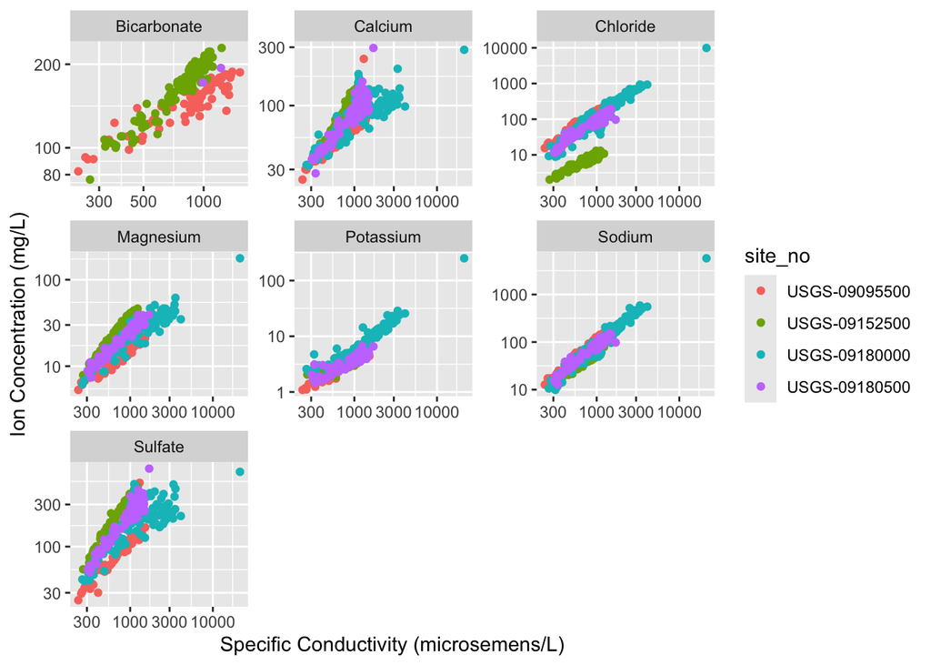

```r
ggplot(joined_data)+
  geom_point(aes(x=SpecCond, y=conc, color=site_no))+
  facet_wrap(facet="parameter", scales = "free")+
  scale_x_log10()+
  scale_y_log10()+
  labs(x= "Specific Conductivity (microsemens/L)",
       y= "Ion Concentration (mg/L)")
```

### Use the `map` and modelling code to test for correlation with `lm`

```r
# Function to run lm on each subset of data
lm_map <- function(df, parameter){
  lm(formula = SpecCond ~ conc, data = df) %>%
    tidy()
}

# Applying lm_map function to each subset of data for each parameter
lm_results <- joined_data %>%
  group_by(parameter) %>%
  nest() %>%
  mutate(model = map2(data, parameter, lm_map)) %>%
  select(-data) %>%
  unnest(cols = c(model)) %>%
  kable(.,'html') %>%
  kable_styling() %>%
  scroll_box(width='600px',height='1000px')

lm_results
```

| parameter | term | estimate | std.error | statistic | p.value |
| --- | --- | --- | --- | --- | --- |
| Bicarbonate | (Intercept) | -170.073848 | 58.5454795 | -2.904987 | 0.0040697 |
| Bicarbonate | conc | 6.290519 | 0.3592816 | 17.508606 | 0.0000000 |
| Calcium | (Intercept) | -414.586525 | 125.3373671 | -3.307765 | 0.0010150 |
| Calcium | conc | 17.530277 | 1.3640089 | 12.852025 | 0.0000000 |
| Chloride | (Intercept) | 775.413906 | 14.6494392 | 52.931303 | 0.0000000 |
| Chloride | conc | 2.201517 | 0.0290843 | 75.694327 | 0.0000000 |
| Magnesium | (Intercept) | -657.647632 | 73.7941343 | -8.911923 | 0.0000000 |
| Magnesium | conc | 69.758467 | 2.6402421 | 26.421239 | 0.0000000 |
| Potassium | (Intercept) | 615.459860 | 14.4569894 | 42.571786 | 0.0000000 |
| Potassium | conc | 87.412508 | 1.0787236 | 81.033280 | 0.0000000 |
| Sodium | (Intercept) | 665.852761 | 13.6429059 | 48.805787 | 0.0000000 |
| Sodium | conc | 3.827271 | 0.0452223 | 84.632377 | 0.0000000 |
| Sulfate | (Intercept) | 218.885238 | 103.6791560 | 2.111179 | 0.0352970 |
| Sulfate | conc | 4.002668 | 0.4255730 | 9.405363 | 0.0000000 |

## Q3) How does discharge control these relationships?

### Free play.

This section is meant to encourage you to play with the data, you definitely will need to download discharge data at our focus sites, but how you explore this question is up to you. What’s the relationship between discharge and SC? Does this relationship alter the relationship between SC and Ions? Does a model with both SC AND discharge predict water quality concentrations better than SC alone? Just try one of these approaches and write out why you think this might be happening.

```r
q_code='00060'

# Retrieve data
q_data <- readNWISdv(siteNumbers = siteNumbers,
                        parameterCd = q_code,
                        startDate = startDate,
                        endDate = endDate) %>%
  renameNWISColumns() %>%
  mutate(site_no=paste0("USGS-",site_no))%>%
  mutate(year=year(.$Date),
    month=month(.$Date),
    Q_ls=Flow*28.315) %>%
  select(date=Date,site_no, Q_ls)

q_joined<-inner_join(joined_data,q_data, by=c("site_no","date"))
```

```r
qnest <- q_joined %>%
  group_by(parameter) %>%
  nest()

# Function to fit linear models
lm_map <- function(df) {
  model <- lm(SpecCond ~ conc * Q_ls, data = df) %>% tidy()
}

# Apply lm_map function to each nested data frame
q_lm_results <- qnest %>%
  mutate(model = map(data, lm_map)) %>%
  unnest(cols = c(model)) %>%
  select(-data)%>%
  kable(.,'html') %>%
  kable_styling() %>%
  scroll_box(width='600px',height='1000px')

q_lm_results
```

| parameter | term | estimate | std.error | statistic | p.value |
| --- | --- | --- | --- | --- | --- |
| Bicarbonate | (Intercept) | 104.7829415 | 84.7606604 | 1.2362214 | 0.2177840 |
| Bicarbonate | conc | 4.9757368 | 0.4874685 | 10.2072991 | 0.0000000 |
| Bicarbonate | Q_ls | -0.0004824 | 0.0006297 | -0.7660770 | 0.4445074 |
| Bicarbonate | conc:Q_ls | -0.0000025 | 0.0000066 | -0.3783238 | 0.7055796 |
| Calcium | (Intercept) | -584.5130841 | 147.3213046 | -3.9676073 | 0.0000844 |
| Calcium | conc | 22.6661073 | 1.6104474 | 14.0744167 | 0.0000000 |
| Calcium | Q_ls | 0.0048406 | 0.0007495 | 6.4582423 | 0.0000000 |
| Calcium | conc:Q_ls | -0.0001223 | 0.0000166 | -7.3866914 | 0.0000000 |
| Chloride | (Intercept) | 867.1992391 | 17.9430313 | 48.3306987 | 0.0000000 |
| Chloride | conc | 2.1630010 | 0.0261588 | 82.6872621 | 0.0000000 |
| Chloride | Q_ls | -0.0010323 | 0.0000966 | -10.6820417 | 0.0000000 |
| Chloride | conc:Q_ls | 0.0000019 | 0.0000029 | 0.6595747 | 0.5098605 |
| Magnesium | (Intercept) | -722.3436247 | 83.0633339 | -8.6962995 | 0.0000000 |
| Magnesium | conc | 79.3389606 | 2.7457400 | 28.8952927 | 0.0000000 |
| Magnesium | Q_ls | 0.0038978 | 0.0004291 | 9.0840974 | 0.0000000 |
| Magnesium | conc:Q_ls | -0.0003371 | 0.0000381 | -8.8559206 | 0.0000000 |
| Potassium | (Intercept) | 666.8680055 | 17.6318194 | 37.8218486 | 0.0000000 |
| Potassium | conc | 85.5908412 | 0.9768871 | 87.6158972 | 0.0000000 |
| Potassium | Q_ls | -0.0015121 | 0.0001949 | -7.7597149 | 0.0000000 |
| Potassium | conc:Q_ls | 0.0003785 | 0.0000997 | 3.7945218 | 0.0001680 |
| Sodium | (Intercept) | 739.4708319 | 17.7306348 | 41.7058296 | 0.0000000 |
| Sodium | conc | 3.7617201 | 0.0407251 | 92.3685356 | 0.0000000 |
| Sodium | Q_ls | -0.0009451 | 0.0000999 | -9.4616381 | 0.0000000 |
| Sodium | conc:Q_ls | 0.0000043 | 0.0000034 | 1.2434834 | 0.2143329 |
| Sulfate | (Intercept) | 240.4523497 | 124.1807699 | 1.9363091 | 0.0534461 |
| Sulfate | conc | 5.2365129 | 0.5227922 | 10.0164330 | 0.0000000 |
| Sulfate | Q_ls | 0.0017109 | 0.0005286 | 3.2365681 | 0.0012977 |
| Sulfate | conc:Q_ls | -0.0000330 | 0.0000055 | -5.9814140 | 0.0000000 |

## Q3) Answer

#### Once we introduce discharge (Q) the ion concentrations begin to change. For example in Bicarbonate Q is not significant meaning that bicarbonate is not really changing with respect to discharge in the basin overall. However things like Calcium, Magnesium, Pottasium, Sodium, and Sulfate, are all correlated with the amount of discharge that occurs.

```r
q_site_nest <- q_joined %>%
  group_by(parameter,site_no) %>%
  nest()

# Function to fit linear models
lm_map <- function(df) {
  lm(SpecCond ~ conc * Q_ls, data = df, na.action = na.omit) %>% tidy()
}

# Apply lm_map function to each nested data frame
q_site_lm_results <- q_site_nest %>%
  mutate(model = map(data, lm_map)) %>%
  unnest(cols = c(model)) %>%
  select(-data)%>%
  filter(term == "conc:Q_ls") %>%
  kable(., 'html') %>%
  kable_styling() %>%
  scroll_box(width='600px', height='1000px')

q_site_lm_results
```

| site_no | parameter | term | estimate | std.error | statistic | p.value |
| --- | --- | --- | --- | --- | --- | --- |
| USGS-09095500 | Bicarbonate | conc:Q_ls | -0.0000402 | 0.0000057 | -7.0055319 | 0.0000000 |
| USGS-09095500 | Calcium | conc:Q_ls | -0.0001588 | 0.0000123 | -12.9477535 | 0.0000000 |
| USGS-09095500 | Chloride | conc:Q_ls | -0.0000042 | 0.0000059 | -0.7104509 | 0.4795991 |
| USGS-09095500 | Magnesium | conc:Q_ls | -0.0002564 | 0.0000395 | -6.4865746 | 0.0000000 |
| USGS-09095500 | Potassium | conc:Q_ls | -0.0012646 | 0.0001863 | -6.7874846 | 0.0000000 |
| USGS-09095500 | Sodium | conc:Q_ls | -0.0000065 | 0.0000099 | -0.6573087 | 0.5130218 |
| USGS-09095500 | Sulfate | conc:Q_ls | -0.0000846 | 0.0000049 | -17.1355949 | 0.0000000 |
| USGS-09152500 | Calcium | conc:Q_ls | -0.0000191 | 0.0000057 | -3.3860286 | 0.0009503 |
| USGS-09152500 | Chloride | conc:Q_ls | 0.0002626 | 0.0001542 | 1.7025366 | 0.0911604 |
| USGS-09152500 | Magnesium | conc:Q_ls | 0.0000148 | 0.0000170 | 0.8694427 | 0.3862849 |
| USGS-09152500 | Potassium | conc:Q_ls | -0.0010801 | 0.0002597 | -4.1595104 | 0.0000591 |
| USGS-09152500 | Sodium | conc:Q_ls | 0.0000056 | 0.0000135 | 0.4172718 | 0.6772012 |
| USGS-09152500 | Sulfate | conc:Q_ls | -0.0000024 | 0.0000008 | -2.8482700 | 0.0051352 |
| USGS-09152500 | Bicarbonate | conc:Q_ls | -0.0000130 | 0.0000045 | -2.9152147 | 0.0042081 |
| USGS-09180000 | Calcium | conc:Q_ls | -0.0012880 | 0.0004342 | -2.9665986 | 0.0036188 |
| USGS-09180000 | Chloride | conc:Q_ls | 0.0000231 | 0.0000285 | 0.8085399 | 0.4203410 |
| USGS-09180000 | Magnesium | conc:Q_ls | -0.0002968 | 0.0009326 | -0.3182993 | 0.7507978 |
| USGS-09180000 | Potassium | conc:Q_ls | 0.0000501 | 0.0006040 | 0.0828993 | 0.9340664 |
| USGS-09180000 | Sodium | conc:Q_ls | 0.0000035 | 0.0000401 | 0.0880988 | 0.9299414 |
| USGS-09180000 | Sulfate | conc:Q_ls | -0.0005439 | 0.0001911 | -2.8461215 | 0.0051867 |
| USGS-09180500 | Calcium | conc:Q_ls | -0.0000409 | 0.0000054 | -7.5609149 | 0.0000000 |
| USGS-09180500 | Chloride | conc:Q_ls | -0.0000209 | 0.0000064 | -3.2953599 | 0.0012927 |
| USGS-09180500 | Magnesium | conc:Q_ls | -0.0000645 | 0.0000153 | -4.2181124 | 0.0000481 |
| USGS-09180500 | Potassium | conc:Q_ls | -0.0006456 | 0.0000840 | -7.6831241 | 0.0000000 |
| USGS-09180500 | Sodium | conc:Q_ls | -0.0000126 | 0.0000053 | -2.3546545 | 0.0201636 |
| USGS-09180500 | Sulfate | conc:Q_ls | -0.0000121 | 0.0000016 | -7.7876930 | 0.0000000 |
| USGS-09180500 | Bicarbonate | conc:Q_ls | NA | NA | NA | NA |

#### To test whether ion concentration matters at an individual site we need to test the interaction of each ion and Q at each site, once we do that we see that ion concentration at each site varies for example sodium now has a significant correlation beteen ion and Q at site USGS-09180500. In cases where the ion concentration is negative is negative the ion is being diluted which is the case with most of the negative estimates.